# Classification2

Hector Corrada Bravo  
CMSC498T Introduction to Data Science, Spring 2015

### Linear Discriminant Analysis

- Another linear method, based on probability model.
- Recall that we want to partition data based on **posterior class probability**: *find the \( \mathbf{X} \) for which* \( P(\mathrm{default=Yes}|X) > P(\mathrm{default=No}|X) \)
- In logistic regression **we made no assumption about \( \mathbf{X} \)**
- In some cases, we **can** make assumptions about \( \mathbf{X} \) that improve prediction performance (if assumptions hold, obviously)

### Linear Discriminant Analysis

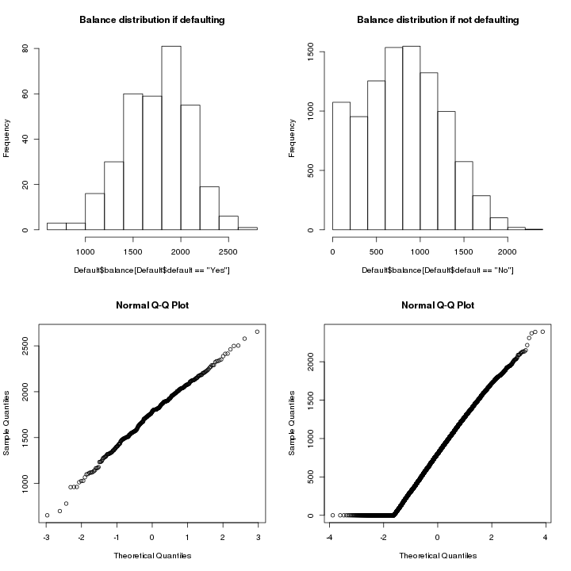

### Linear Discriminant Analysis

- This implies we can model `balance` for each of the classes with a normal distribution
- WARNING, BIG ASSUMPTION: We will assume `balance` has the same *variance* for both classes (this is what makes LDA linear)
- So, we estimate average `balance` for people who *do not* default:

\[ \hat{\mu}_0 = \frac{1}{n_0} \sum_{i:\, y_i=0} x_i \]

- And for people who do default:

\[ \hat{\mu}_1 = \frac{1}{n_1} \sum_{i:\, y_i=1} x_i \]

### Linear Discriminant Analysis

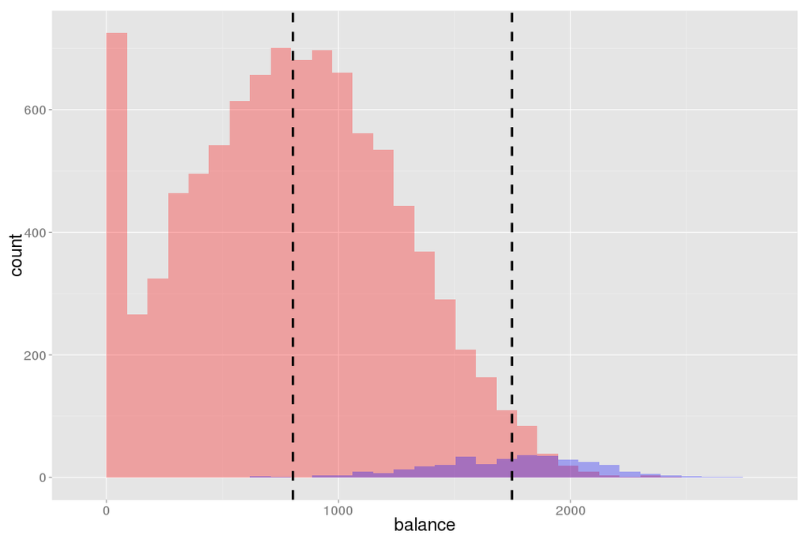

### Linear Discriminant Analysis

- This implies we can model `balance` for each of the classes with a normal distribution
- WARNING, BIG ASSUMPTION: We will assume `balance` has the same *variance* for both classes (this is what makes LDA linear)
- And estimate variance for both classes as

\[ \hat{\sigma}^2 = \frac{1}{n-2} \sum_{k=1,2} \sum_{i:\, y_i=k} (x_i - \hat{\mu}_k)^2 \]

### Linear Discriminant Analysis

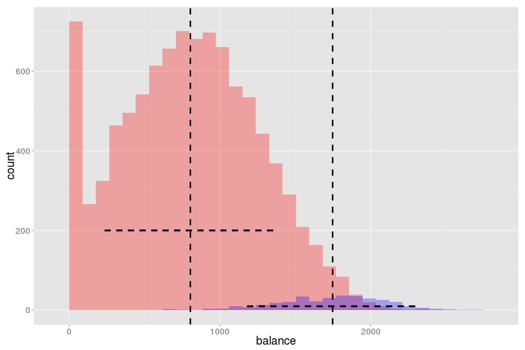

### Linear Discriminant Analysis

We can “score” values of `balance` based on these estimates:

\[ f_k(x) = \frac{1}{\sqrt{2\pi}\sigma} \exp \left(-\frac{1}{2\sigma^2} (x-\mu_k)^2 \right) \]

### Linear Discriminant Analysis

- Remember, what we want is **posterior class probability** \( P(Y=k|X) \), for that we need to include the probability that we *observe* class \( k \).
- This is called **prior class probability**, denoted \( \pi_k \), means the proportion of times you expect people to default regardless of any other attribute. We can estimate from training data as the proportion of observations with label \( k \).

### Linear Discriminant Analysis

- Bayes' Rule (or Theorem) gives us a way of computing \( P(Y=k|X) \) using score \( f_k(x) \) (from the class normal assumption) and prior \( \pi_k \):

\[ P(Y=k|X) = \frac{f_k(x) \pi_k}{\sum_l f_l(x) \pi_l} \]

- If data (conditioned by class) is distributed so that \( f_k \) is the right probability function to use, then
- Predicting the class that maximizes \( P(Y=k|X) \) is the **optimal** thing to do.
- This is referred to the *Bayes classifier* (aka the Holy Grail of classification)

### Linear Discriminant Analysis

**How to train LDA**

Compute class means and squared error based on class mean

```r
lda_stats <- Default %>%
  group_by(default) %>%
  mutate(class_mean=mean(balance),
         squared_error=(balance-class_mean)^2)
```

### Linear Discriminant Analysis

**How to train LDA**

Compute class sizes and sum of squared errors

```r
lda_stats <- lda_stats %>%
  summarize(class_mean=first(class_mean),
            class_size=n(),
            sum_squares=sum(squared_error))
```

### Linear Discriminant Analysis

**How to train LDA**

Compute class prior and variance (note same variance for both classes)

```r
lda_stats <- lda_stats %>%
  mutate(class_prior=class_size/sum(class_size),
         sigma2=sum(sum_squares) / (sum(class_size) - 2)) %>%
  select(default, class_mean, class_prior, sigma2)

kable(lda_stats)
```

| default | class_mean | class_prior | sigma2 |
| --- | --- | --- | --- |
| No | 803.9438 | 0.9667 | 205318.6 |
| Yes | 1747.8217 | 0.0333 | 205318.6 |

### Linear Discriminant Analysis (predict)

How do we predict with LDA?

- Predict `Yes` if \( P(Y=1|X) > P(Y=0|X) \)
- Equivalently:

\[ \log{\frac{P(Y=1|X)}{P(Y=0|X)}} > 0 \Rightarrow \\ \log f_1(x) + \log \pi_1 > \log f_0(x) + \log \pi_0 \]

- This turns out to be a linear function of \( x \)!

### Linear Discriminant Analysis (predict)

```r
lda_log_ratio <- function(balance, lda_stats) {
  n <- length(balance)

  # subtract class mean
  centered_balance <- rep(balance, 2) - rep(lda_stats$class_mean, each=n)

  # scale by standard deviation
  scaled_balance <- centered_balance / sqrt(lda_stats$sigma2[1])

  # compute log normal density and add log class prior
  lprobs <- dnorm(scaled_balance, log=TRUE) + rep(lda_stats$class_prior, each=n)

  # compute log ratio of class probabilities
  lprobs <- matrix(lprobs, nc=2)
  colnames(lprobs) <- lda_stats$default
  lprobs[,"Yes"] - lprobs[,"No"]
}
```

### Linear Discriminant Analysis (predict)

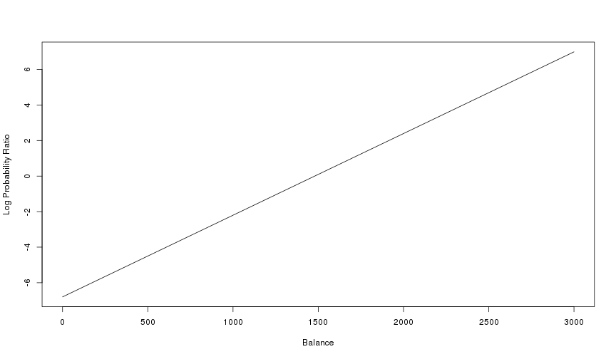

```r
test_balance <- seq(0, 3000, len=100)
plot(test_balance, lda_log_ratio(test_balance, lda_stats),
     type="l", xlab="Balance", ylab="Log Probability Ratio", cex=1.4)
```

### Quadratic Discriminant Analysis

We can get a quadratic decision boundary by letting each class have it's own variance

```r
qda_stats <- qda_stats %>%
  summarize(class_mean=first(class_mean),
            class_size=n(),
            class_sigma2=sum(squared_error) / (class_size - 1))
```

| default | class_mean | class_prior | class_sigma2 |
| --- | --- | --- | --- |
| No | 803.9438 | 0.9667 | 208370.6 |
| Yes | 1747.8217 | 0.0333 | 116463.0 |

### Quadratic Discriminant Analysis

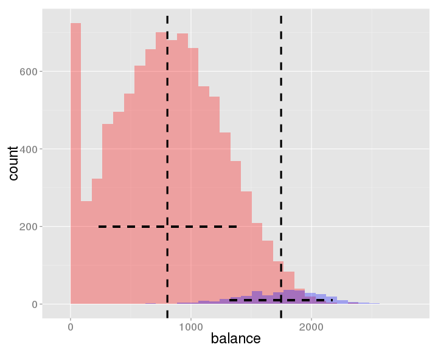

### Quadratic Discriminant Analysis

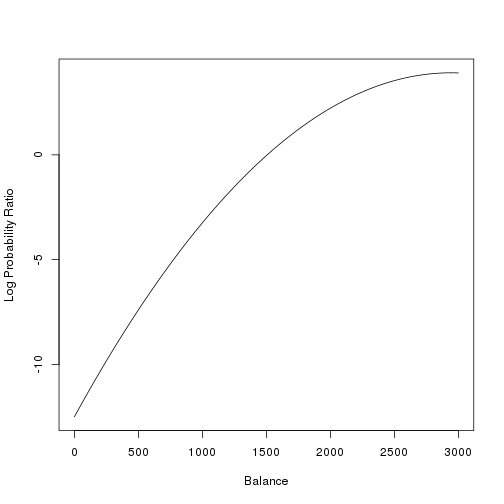

### Evaluation

How well did LDA do?

```r
library(MASS)
lda_fit <- lda(default ~ balance, data=Default)
lda_pred <- predict(lda_fit, data=Default)
print(table(predicted=lda_pred$class, observed=Default$default))
```

```
         observed
predicted   No  Yes
      No  9643  257
      Yes   24   76
```

```r
# error rate
mean(Default$default != lda_pred$class) * 100
```

```
[1] 2.81
```

### Evaluation

How well did LDA do?

Not very well, we can get similar error rate by always predicting “no default”

- From table above, LDA errors are not symmetric, most common error is that *it misses true defaults*
- Also, when can we say a classifier is better than another classifier? (next lecture)

```r
# LDA error rate
mean(Default$default != lda_pred$class) * 100
```

```
[1] 2.81
```

```r
# dummy error rate
mean(Default$default != "No") * 100
```

```
[1] 3.33
```

### Evaluation

Need a more precise language to describe classification errors:

|  | True Class + | True Class - | Total |
| --- | --- | --- | --- |
| Predicted Class + | True Positive (TP) | False Positive (FP) | T* |
| Predicted Class - | False Negative (FN) | True Negative (TN) | F* |
| Total | T | F |  |

```
         observed
predicted   No  Yes
      No  9643  257
      Yes   24   76
```

### Evaluation

Need a more precise language to describe classification errors:

|  | True Class + | True Class - | Total |
| --- | --- | --- | --- |
| Predicted Class + | True Positive (TP) | False Positive (FP) | P* |
| Predicted Class - | False Negative (FN) | True Negative (TN) | N* |
| Total | P | N |  |

[output not shown]

In the credit default case we may want to increase **TPR** (recall, make sure we catch all defaults) at the expense of **FPR** (1-Specificity, clients we lose because we think they will default)

### Evaluation

How can we adjust TPR and FPR?

Remember we are classifying `Yes` if

\[ \log \frac{P(Y=\mathtt{Yes}|X)}{P(Y=\mathtt{No}|X)} > 0 \Rightarrow \\ P(Y=\mathtt{Yes}|X) > 0.5 \]

What would happen if we use \( P(Y=\mathtt{Yes}|X) > 0.2 \)?

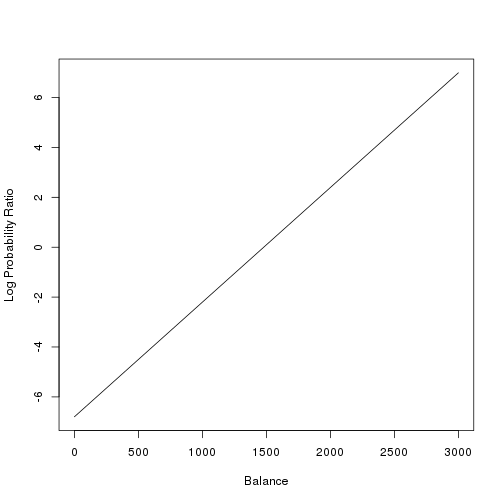

### Evaluation

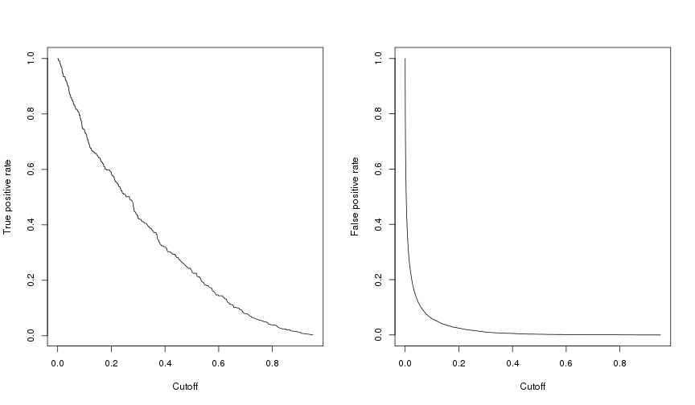

```r
library(ROCR)
pred <- prediction(lda_pred$posterior[,"Yes"], Default$default)

layout(cbind(1,2))
plot(performance(pred, "tpr"))
plot(performance(pred, "fpr"))
```

### Evaluation

- **ROC curve** (Receiver Operating Characteristic)
- **AUROC** (area under the ROC)

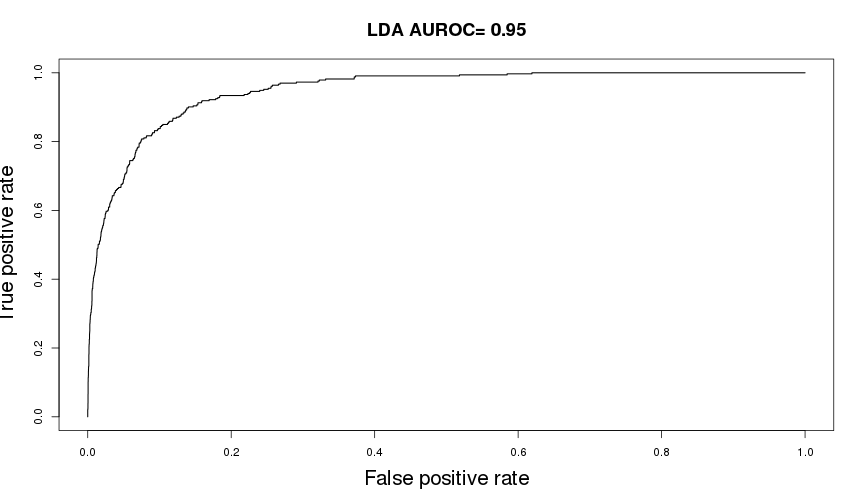

```r
auc <- unlist(performance(pred, "auc")@y.values)
plot(performance(pred, "tpr", "fpr"),
     main=paste("LDA AUROC=", round(auc, 2)),
     lwd=1.4, cex.lab=1.7, cex.main=1.5)
```

### Evaluation

```r
full_lda <- lda(default~., data=Default)
full_lda_preds <- predict(full_lda, Default)

pred_list <- list(
  balance_lda = lda_pred$posterior[,"Yes"],
  full_lda = full_lda_preds$posterior[,"Yes"],
  dummy = rep(0, nrow(Default)))

pred_objs <- lapply(pred_list,
  prediction, Default$default)

aucs <- sapply(pred_objs,
  function(x) unlist(
    performance(x, "auc")@y.values))

roc_objs <- lapply(pred_objs,
  performance, "tpr", "fpr")
```

### Evaluation

```r
for (i in seq(along=roc_objs)) {
  plot(roc_objs[[i]], add = i != 1, col=i,
       lwd=3, cex.lab=1.5)
}
legend("bottomright",
       legend=paste(gsub("_", " ", names(pred_list)), "AUROC=",round(aucs, 2)),
       col=1:3, lwd=3, cex=2)
```

### Evaluation

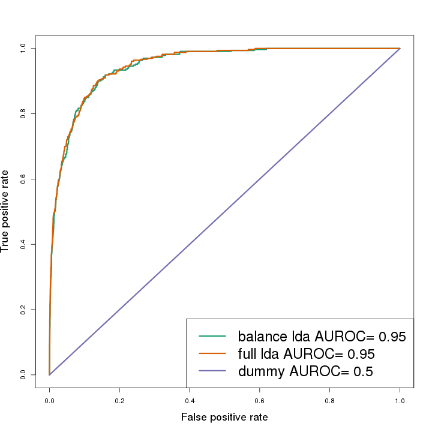

### Evaluation

Also consider the precision-recall curve:

```r
library(caTools)
pr_objs <- lapply(pred_objs,
  performance, "prec", "rec")

for (i in seq(along=pr_objs)) {
  plot(pr_objs[[i]], add = i != 1, col=i,
       lwd=3, cex.lab=1.5)
}
legend("bottomleft",
       legend=paste(gsub("_", " ", names(pred_list))),
      col=1:3, lwd=3, cex=2)
```

### Evaluation

Also consider the precision-recall curve:

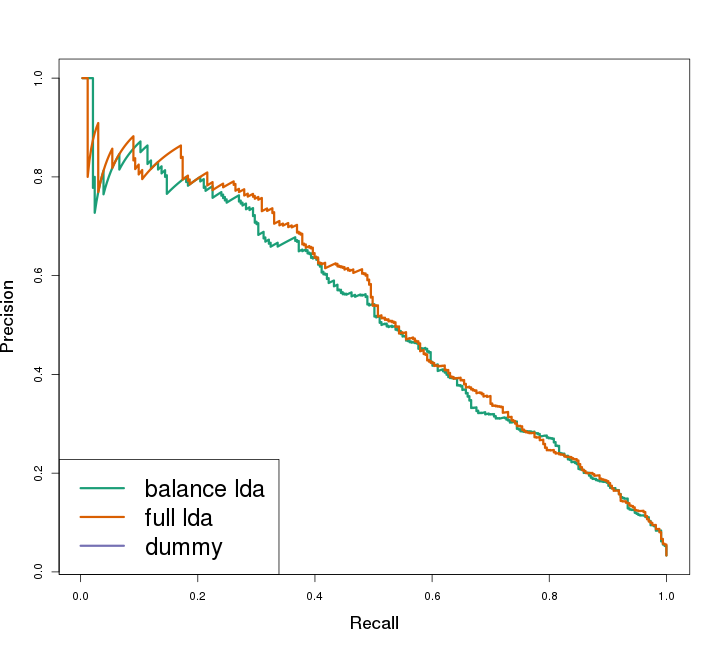

### K Nearest neighbor classifier

Use `knn` function in package `class`

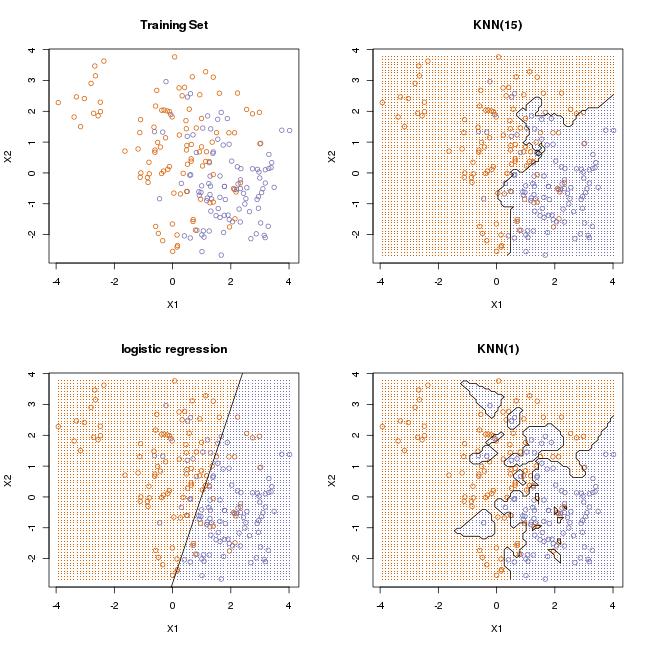

### Summary

- Think of classification as a class probability estimation problem
- Logistic regression and LDA partition predictor space with linear functions:
  - logistic regression learns parameter using Maximum Likelihood (numerical optimization)
  - LDA learns parameter using means and variances (and assuming normal distribution)
- K nearest neighbor nonlinear, but easy to overfit

### Summary

- Error and accuracy not enough to understand classifier performance
- Classifications can be done using probability cutoffs to trade, e.g., TPR-FPR (ROC curve), or precision-recall (PR curve)
- Area under ROC or PR curve summarize classifier performance across different cutoffs